# Sound Life Cohort — Exploratory Data Analysis

Whole Blood RNA-seq & Plasma Proteomics

2026-06-16

```r
library(anndataR)
library(Seurat)
library(SeuratObject)
library(dplyr)
library(tidyr)
library(ggplot2)
library(naniar)
library(variancePartition)
```

# Overview

This document explores three datasets from the **Sound Life Cohort** — a study that followed healthy young adults (ages 25–35) and older adults (ages 55–65) from the Seattle area over multiple years, collecting blood samples at regular visits. The goal of this EDA is to understand what we have, check data quality, and identify anything that needs to be accounted for when building the Bayesian model.

[output not shown]

# 1. Data Loading

```r
whole_nostim <- read_h5ad(
  "~/Downloads/sound-life_whole-blood_no-stim_copy.h5ad",
  as = "Seurat"
)

whole_exvivo <- read_h5ad(
  "~/Downloads/sound-life_whole-blood_ex-vivo-stim_copy.h5ad",
  as = "Seurat"
)

plasma <- read.csv("~/Downloads/sound_life_all_olink_copy.csv")
```

# 2. Whole Blood RNA-seq — Unstimulated

## 2.1 Dataset Size

```r
dim(whole_nostim)
```

```
## [1] 58302   838
```

> We have measurements for **58,302 genes across 838 blood samples**. Each sample comes from one person at one visit. The expected number was 836, so two extra samples are present — likely duplicates or administrative entries. Not a problem for exploration, but worth checking before modeling.

## 2.2 Who Is in the Study?

```r
cat("Biological Sex \n")
```

```
## Biological Sex
```

```r
table(whole_nostim$subject.biologicalSex)
```

```
##
## Female   Male
##    479    359
```

```r
cat("\n Age Group \n")
```

```
##
##  Age Group
```

```r
table(whole_nostim$subject.ageGroup)
```

```
##
## Older Adult Young Adult
##         440         398
```

```r
cat("\n CMV Status \n")
```

```
##
##  CMV Status
```

```r
table(whole_nostim$subject.cmv)
```

```
##
## Negative Positive
##      456      382
```

```r
cat("\n BMI \n")
```

```
##
##  BMI
```

```r
summary(whole_nostim$subject.bmi)
```

```
##    Min. 1st Qu.  Median    Mean 3rd Qu.    Max.    NA's
##   19.00   23.00   26.00   26.47   29.00   43.00      37
```

> - **Sex:** Roughly balanced — about 57% female, 43% male across samples.
> - **Age group:** Fairly even split between Older Adults (~53%) and Young Adults (~47%).
> - **CMV status:** CMV (cytomegalovirus) is a common, usually harmless virus that most people catch at some point in life. Once infected, it stays in your body permanently and is known to have lasting effects on the immune system. About 46% of participants here have been infected (CMV Positive), 54% have not.
> - **BMI:** The average BMI is about 26, with a healthy range across participants. Notably, 37 samples are missing a BMI value — these belong to a subset of subjects, and we’ll need to handle this gap in the model (either by estimating the missing values or including a flag for “BMI unknown”).

## 2.3 Does CMV Status Vary by Age Group?

```r
tab <- table(whole_nostim$subject.ageGroup, whole_nostim$subject.cmv)
tab
```

```
##
##               Negative Positive
##   Older Adult      203      237
##   Young Adult      253      145
```

```r
prop.table(tab, margin = 1)
```

```
##
##                Negative  Positive
##   Older Adult 0.4613636 0.5386364
##   Young Adult 0.6356784 0.3643216
```

> About 54% of Older Adults have been infected with CMV, compared to only 36% of Young Adults.

## 2.4 Is Sex Balanced Within Age Groups?

```r
table(whole_nostim$subject.ageGroup, whole_nostim$subject.biologicalSex)
```

```
##
##               Female Male
##   Older Adult    250  190
##   Young Adult    229  169
```

> Sex is evenly distributed within both age groups.

## 2.5 How Good Is the Sequencing Data?

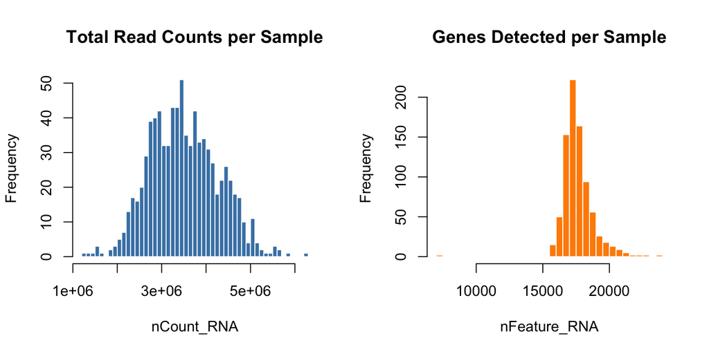

```r
par(mfrow = c(1, 2))

hist(whole_nostim$nCount_RNA, breaks = 50,
     main = "Total Read Counts per Sample", xlab = "nCount_RNA",
     col = "steelblue", border = "white")

hist(whole_nostim$nFeature_RNA, breaks = 50,
     main = "Genes Detected per Sample", xlab = "nFeature_RNA",
     col = "darkorange", border = "white")
```

```r
par(mfrow = c(1, 1))

summary(whole_nostim$nCount_RNA)
```

```
##    Min. 1st Qu.  Median    Mean 3rd Qu.    Max.
## 1220532 2934030 3458768 3509205 4036887 6272204
```

```r
summary(whole_nostim$nFeature_RNA)
```

```
##    Min. 1st Qu.  Median    Mean 3rd Qu.    Max.
##    7083   16977   17451   17628   18098   23907
```

## 2.6 How Was the Study Structured Over Time?

```r
meta <- whole_nostim@meta.data %>%
  mutate(
    event = case_when(
      grepl("Flu Year 1", sample.visitName)       ~ "Flu_Y1",
      grepl("Flu Year 2", sample.visitName)       ~ "Flu_Y2",
      grepl("Immune Variation", sample.visitName) ~ "ImVar",
      TRUE ~ "StandAlone"
    ),
    within_event_day = case_when(
      grepl("Day 0",  sample.visitName) ~ 0,
      grepl("Day 7",  sample.visitName) ~ 7,
      grepl("Day 90", sample.visitName) ~ 90,
      TRUE ~ NA_real_
    ),
    include_in_model = !is.na(within_event_day)
  )

cat(" Number of Samples Collected at Each Visit:  \n")
```

```
##  Number of Samples Collected at Each Visit:
```

```r
table(meta$sample.visitName)
```

```
##
##        Flu Year 1 Day 0        Flu Year 1 Day 7       Flu Year 1 Day 90
##                      92                      88                      86
##  Flu Year 1 Stand-Alone        Flu Year 2 Day 0        Flu Year 2 Day 7
##                      14                      81                      79
##       Flu Year 2 Day 90  Flu Year 2 Stand-Alone  Flu Year 3 Stand-Alone
##                      78                      21                      47
##  Immune Variation Day 0  Immune Variation Day 7 Immune Variation Day 90
##                      87                      85                      80
```

```r
cat("\n Event x Within-event day \n")
```

```
##
##  Event x Within-event day
```

```r
table(meta$event, meta$within_event_day, useNA = "ifany")
```

```
##
##               0  7 90 <NA>
##   Flu_Y1     92 88 86   14
##   Flu_Y2     81 79 78   21
##   ImVar      87 85 80    0
##   StandAlone  0  0  0   47
```

> Visits were organized around specific biological events:
> - **Flu vaccination visits (Years 1 & 2):** Blood was drawn before the flu shot (Day 0), one week after (Day 7, capturing the acute immune response), and three months later (Day 90, capturing immune memory).
> - **Immune Variation visits:** Same Day 0 / 7 / 90 structure but without flu vaccination to capture natural immune variation over time.
> - **Stand-Alone visits (82 samples):** These are extra draws that don’t fit the structured Day 0/7/90 pattern. Can’t be placed in a consistent timeline relative to an event.

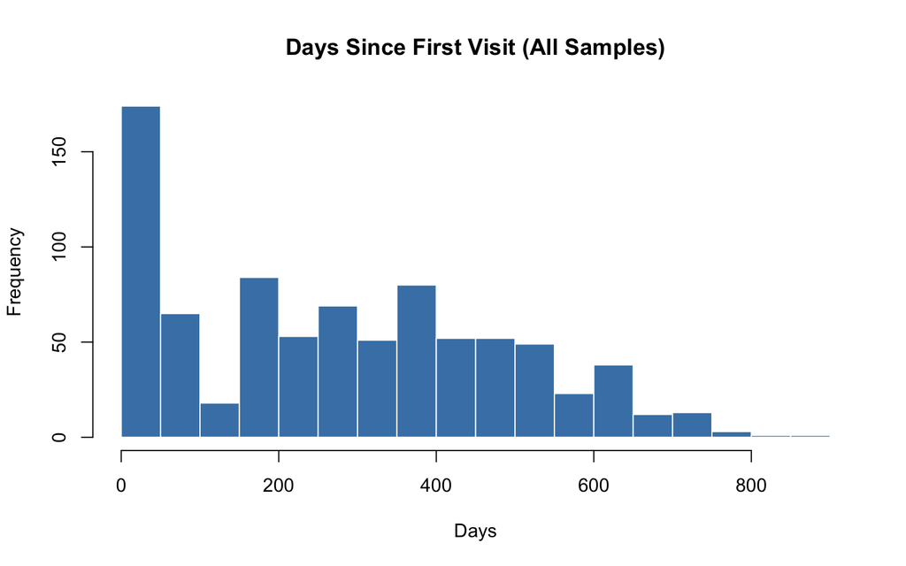

```r
hist(whole_nostim@meta.data$sample.daysSinceFirstVisit, breaks = 30,
     main = "Days Since First Visit (All Samples)",
     xlab = "Days", col = "steelblue", border = "white")
```

## 2.7 Did Participants Stay in the Study?

```r
visit_counts <- whole_nostim@meta.data %>%
  group_by(subject.subjectGuid, subject.ageGroup) %>%
  summarise(n_visits = n(), .groups = "drop")

cat("How many visits per subject? \n")
```

```
## How many visits per subject?
```

```r
table(visit_counts$n_visits)
```

```
##
##  1  2  3  4  5  6  7  8  9 10 11
##  1  5  3  1  3  3  2  3  9 64  2
```

```r
visit_counts %>%
  group_by(subject.ageGroup) %>%
  summarise(
    mean_visits  = round(mean(n_visits), 2),
    min_visits   = min(n_visits),
    max_visits   = max(n_visits),
    n_complete   = sum(n_visits == 10),
    n_incomplete = sum(n_visits < 10)
  )
```

```
## # A tibble: 2 × 6
##   subject.ageGroup mean_visits min_visits max_visits n_complete n_incomplete
##   <fct>                  <dbl>      <int>      <int>      <int>        <int>
## 1 Older Adult             9.36          1         10         38            9
## 2 Young Adult             8.12          2         11         26           21
```

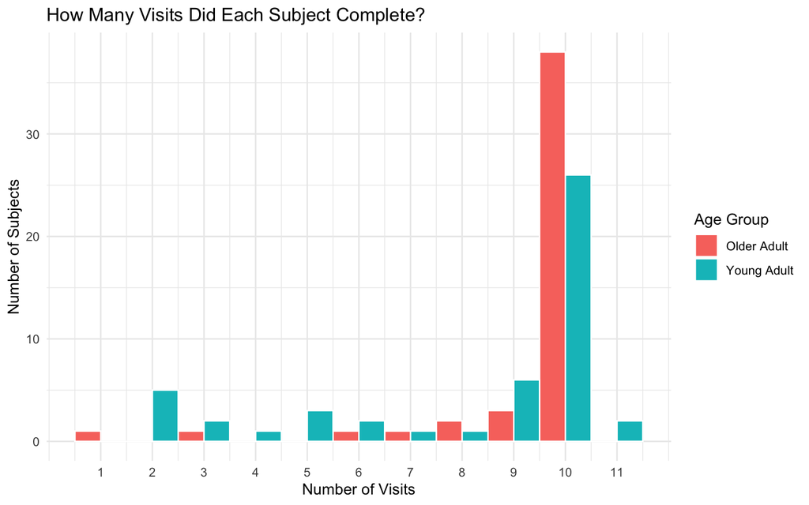

```r
visit_counts %>%
  ggplot(aes(x = n_visits, fill = subject.ageGroup)) +
  geom_histogram(binwidth = 1, position = "dodge", color = "white") +
  scale_x_continuous(breaks = 1:11) +
  labs(
    title = "How Many Visits Did Each Subject Complete?",
    x     = "Number of Visits",
    y     = "Number of Subjects",
    fill  = "Age Group"
  ) +
  theme_minimal()
```

```r
visit_counts %>%
  filter(subject.ageGroup == "Young Adult") %>%
  left_join(
    whole_nostim@meta.data %>%
      select(subject.subjectGuid, subject.biologicalSex, subject.cmv) %>%
      distinct(),
    by = "subject.subjectGuid"
  ) %>%
  group_by(subject.biologicalSex, subject.cmv) %>%
  summarise(
    mean_visits  = round(mean(n_visits), 2),
    n_complete   = sum(n_visits == 10),
    n_incomplete = sum(n_visits < 10),
    .groups = "drop"
  )
```

```
## # A tibble: 4 × 5
##   subject.biologicalSex subject.cmv mean_visits n_complete n_incomplete
##   <fct>                 <fct>             <dbl>      <int>        <int>
## 1 Female                Negative           8.72         12            5
## 2 Female                Positive           7.2           2            7
## 3 Male                  Negative           8             6            6
## 4 Male                  Positive           8.11          6            3
```

> Most participants completed all 10 scheduled visits, but there is some dropout:
> - **Older Adults** were better retained (average 9.4 visits; 38 out of 47 completed all 10).
> - **Young Adults** had more dropout (average 8.1 visits; only 26 out of 49 completed all 10).
> - Among Young Adults, CMV-positive females had notably fewer visits on average (7.2) and the lowest completion rate (only 2 out of 9 finished).

## 2.8 Which Genes Vary the Most?

```r
mat_nostim <- GetAssayData(whole_nostim, layer = "X")
gene_var    <- apply(mat_nostim, 1, var)
top_genes   <- names(sort(gene_var, decreasing = TRUE))[1:50]

cat("Top 20 most variable genes across all samples:\n")
```

```
## Top 20 most variable genes across all samples:
```

```r
head(top_genes, 20)
```

```
##  [1] "ACTB"     "ALAS2"    "MT-RNR2"  "SLC25A39" "FTL"      "HBB"
##  [7] "TXNIP"    "B2M"      "HLA-B"    "PSAP"     "S100A9"   "HLA-E"
## [13] "CD74"     "ADIPOR1"  "LCP1"     "HLA-C"    "HBG2"     "IGHG1"
## [19] "MALAT1"   "IGHA1"
```

> These are the genes whose activity levels differ the most across samples.

## 2.9 What Is Actually Driving Gene Expression Differences?

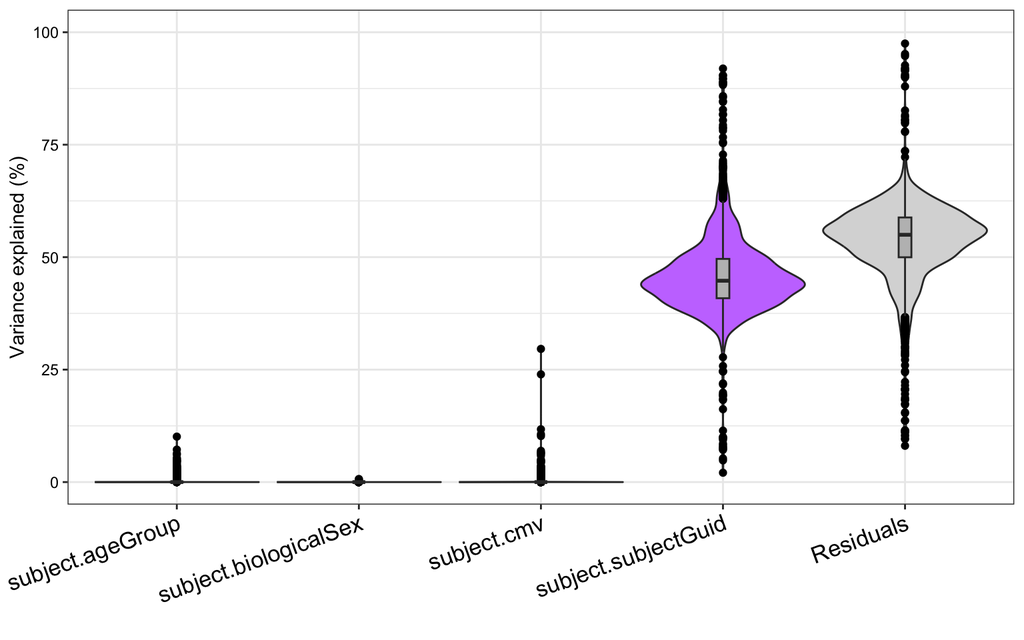

```r
gene_var_all <- apply(mat_nostim, 1, var)
top2k        <- names(sort(gene_var_all, decreasing = TRUE))[1:2000]
mat_subset   <- mat_nostim[top2k, ]

vp_meta <- whole_nostim@meta.data %>%
  select(
    subject.subjectGuid,
    subject.ageGroup,
    subject.cmv,
    subject.biologicalSex,
    sample.daysSinceFirstVisit
  )
vp_meta <- vp_meta[colnames(mat_subset), ]

form <- ~ (1|subject.subjectGuid) + (1|subject.ageGroup) +
          (1|subject.cmv) + (1|subject.biologicalSex)

vp <- fitExtractVarPartModel(mat_subset, form, vp_meta)
plotVarPart(vp)
```

> For the 2,000 most variable genes, what is actually responsible for the variation we see?

> Each violin in the plot represents one source of variation, and its width shows how much that source explains across genes:
> - **`subject.subjectGuid` (individual identity):** Larger violin means most gene-to-gene variation is just people being different from each other.
> - **`subject.ageGroup`:** How much of the variation is explained by being Young vs. Old.
> - **`subject.cmv`:** How much is driven by CMV infection history.
> - **`subject.biologicalSex`:** How much is driven by sex differences.
> - **`Residuals`:** A substantial portion of gene expression variation isn’t explained by any of the four factors tested — likely driven by visit-to-visit fluctuations, vaccination timing, or biology not captured by these variables alone.

# 3. Whole Blood RNA-seq — Ex Vivo Stimulation

## 3.1 Dataset Size & Stimulation Balance

```r
dim(whole_exvivo)
```

```
## [1] 58302   985
```

```r
table(whole_exvivo$geo.stimulation)
```

```
##
##      LPS     Null Poly I:C      SEB
##      247      246      243      249
```

> This dataset has **985 samples** — more than the unstimulated set because each blood draw was split into four tubes, one per condition:
> - **Null:** No stimulus added — the control condition
> - **LPS:** A bacterial cell wall component; triggers a strong innate immune response
> - **SEB:** A toxin from Staph bacteria; activates T cells
> - **Poly I:C:** Mimics a viral infection; triggers antiviral immune pathways

## 3.2 Sequencing Quality

```r
summary(whole_exvivo$nCount_RNA)
```

```
##    Min. 1st Qu.  Median    Mean 3rd Qu.    Max.
## 1040960 2849766 3461956 3475508 4068707 6513609
```

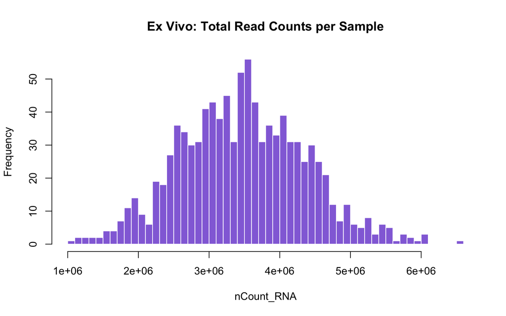

```r
hist(whole_exvivo$nCount_RNA, breaks = 50,
     main = "Ex Vivo: Total Read Counts per Sample",
     xlab = "nCount_RNA",
     col  = "mediumpurple", border = "white")
```

## 3.3 Does Stimulation Separate Samples?

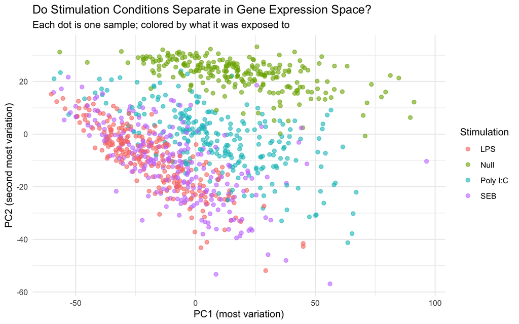

```r
DefaultAssay(whole_exvivo) <- "RNA"
mat_exvivo  <- LayerData(whole_exvivo, layer = "X")

gv_exvivo   <- apply(mat_exvivo, 1, var)
top_exvivo  <- names(sort(gv_exvivo, decreasing = TRUE))[1:2000]
mat_exvivo2 <- mat_exvivo[top_exvivo, ]

pca_exvivo  <- prcomp(t(mat_exvivo2), scale. = TRUE)

pca_df <- data.frame(
  PC1       = pca_exvivo$x[, 1],
  PC2       = pca_exvivo$x[, 2],
  stim      = whole_exvivo$geo.stimulation,
  age_group = whole_exvivo$subject.ageGroup
)

ggplot(pca_df, aes(x = PC1, y = PC2, color = stim)) +
  geom_point(alpha = 0.6, size = 1.8) +
  labs(
    title    = "Do Stimulation Conditions Separate in Gene Expression Space?",
    subtitle = "Each dot is one sample; colored by what it was exposed to",
    x = "PC1 (most variation)", y = "PC2 (second most variation)",
    color = "Stimulation"
  ) +
  theme_minimal()
```

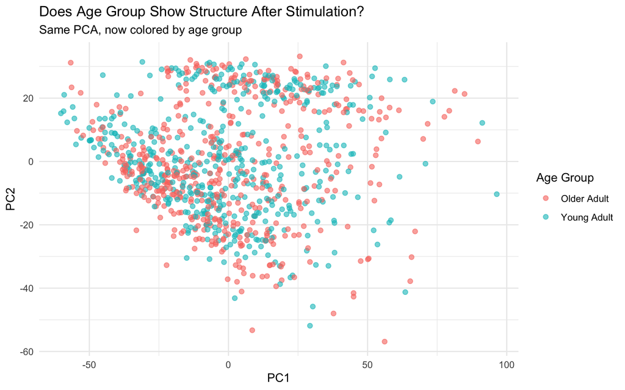

```r
ggplot(pca_df, aes(x = PC1, y = PC2, color = age_group)) +
  geom_point(alpha = 0.6, size = 1.8) +
  labs(
    title    = "Does Age Group Show Structure After Stimulation?",
    subtitle = "Same PCA, now colored by age group",
    x = "PC1", y = "PC2",
    color = "Age Group"
  ) +
  theme_minimal()
```

# 4. Plasma Proteomics (Olink)

## 4.1 Data Structure

```r
cat("Dimensions (long format):", nrow(plasma), "rows x", ncol(plasma), "cols\n")
```

```
## Dimensions (long format): 1274064 rows x 26 cols
```

```r
cat("Unique proteins measured:", n_distinct(plasma$olink.assay), "\n")
```

```
## Unique proteins measured: 1472
```

```r
cat("Unique samples:", n_distinct(plasma$sample.sampleKitGuid), "\n")
```

```
## Unique samples: 867
```

```r
cat("Duplicate sample x protein rows:", sum(duplicated(plasma[, c("sample.sampleKitGuid", "olink.assay")])), "\n")
```

```
## Duplicate sample x protein rows: 7803
```

## 4.2 Reshape to Wide Format

```r
plasma_wide <- plasma %>%
  select(sample.sampleKitGuid, olink.assay, olink.NPX_norm) %>%
  pivot_wider(
    names_from  = olink.assay,
    values_from = olink.NPX_norm,
    values_fn   = mean
  )

cat("Wide format dimensions:", nrow(plasma_wide), "samples x", ncol(plasma_wide) - 1, "proteins\n")
```

```
## Wide format dimensions: 867 samples x 1472 proteins
```

## 4.3 How Well Do the Datasets Overlap?

```r
common_plas_nostim   <- intersect(plasma_wide$sample.sampleKitGuid, whole_nostim$sample.sampleKitGuid)
common_plas_exvivo   <- intersect(plasma_wide$sample.sampleKitGuid, whole_exvivo$sample.sampleKitGuid)
common_exvivo_nostim <- intersect(whole_nostim$sample.sampleKitGuid, whole_exvivo$sample.sampleKitGuid)

cat("Plasma + RNA (nostim) matched samples:", length(common_plas_nostim), "\n")
```

```
## Plasma + RNA (nostim) matched samples: 835
```

```r
cat("Plasma + RNA (exvivo) matched samples:", length(common_plas_exvivo), "\n")
```

```
## Plasma + RNA (exvivo) matched samples: 254
```

```r
cat("Nostim + Exvivo shared sample kits:   ", length(common_exvivo_nostim), "\n")
```

```
## Nostim + Exvivo shared sample kits:    247
```

```r
cat("Plasma-only (no RNA match):           ", nrow(plasma_wide) - length(common_plas_nostim), "\n")
```

```
## Plasma-only (no RNA match):            32
```

```r
cat("RNA-only (no plasma match):           ", ncol(whole_nostim) - length(common_plas_nostim), "\n")
```

```
## RNA-only (no plasma match):            3
```

> 835 out of 838 RNA-seq samples have a matching plasma sample. This is important because it means we can analyze gene expression and protein levels from the same blood draw.

> The small number of non-overlapping samples (32 plasma-only, 3 RNA-only) is likely due to occasional sample processing failures rather than participants dropping out.

```r
subject_meta <- whole_nostim@meta.data %>%
  select(
    sample.sampleKitGuid, subject.subjectGuid, subject.ageGroup,
    subject.biologicalSex, subject.cmv, subject.bmi,
    subject.race, subject.ethnicity, subject.ageAtFirstDraw,
    sample.subjectAgeAtDraw, sample.daysSinceFirstVisit, sample.visitName
  ) %>%
  distinct()

unmatched_plasma <- plasma$sample.sampleKitGuid[
  !plasma$sample.sampleKitGuid %in% whole_nostim$sample.sampleKitGuid
]

plasma %>%
  filter(sample.sampleKitGuid %in% unmatched_plasma) %>%
  select(sample.sampleKitGuid, subject.subjectGuid,
         sample.visitName, subject.ageGroup) %>%
  distinct() %>%
  count(subject.ageGroup, sample.visitName) %>%
  arrange(subject.ageGroup, sample.visitName)
```

```
##    subject.ageGroup        sample.visitName n
## 1       Older Adult        Flu Year 1 Day 7 2
## 2       Older Adult       Flu Year 1 Day 90 1
## 3       Older Adult        Flu Year 2 Day 7 2
## 4       Older Adult       Flu Year 2 Day 90 2
## 5       Older Adult  Immune Variation Day 7 2
## 6       Older Adult Immune Variation Day 90 1
## 7       Young Adult        Flu Year 1 Day 0 1
## 8       Young Adult        Flu Year 1 Day 7 3
## 9       Young Adult       Flu Year 1 Day 90 2
## 10      Young Adult        Flu Year 2 Day 0 3
## 11      Young Adult        Flu Year 2 Day 7 3
## 12      Young Adult       Flu Year 2 Day 90 2
## 13      Young Adult  Flu Year 2 Stand-Alone 1
## 14      Young Adult  Immune Variation Day 0 2
## 15      Young Adult  Immune Variation Day 7 2
## 16      Young Adult Immune Variation Day 90 3
```

> The 32 unmatched plasma samples are scattered across visit types and both age groups with no obvious pattern. Consistent with random processing failures rather than systematic loss of a particular subgroup.

## 4.4 Can We Trust All Protein Measurements?

```r
lod_summary <- plasma %>%
  mutate(below_lod = olink.NPX_norm < olink.LOD_norm) %>%
  group_by(olink.assay) %>%
  summarise(pct_below_lod = mean(below_lod, na.rm = TRUE)) %>%
  arrange(desc(pct_below_lod))

cat("Proteins where >50% of measurements are below the detection threshold:", sum(lod_summary$pct_below_lod > 0.50), "\n")
```

```
## Proteins where >50% of measurements are below the detection threshold: 151
```

```r
cat("Proteins where >30% of measurements are below the detection threshold:", sum(lod_summary$pct_below_lod > 0.30), "\n")
```

```
## Proteins where >30% of measurements are below the detection threshold: 217
```

```r
cat("Proteins where <=10% of measurements are below the detection threshold:", sum(lod_summary$pct_below_lod <= 0.10), "\n")
```

```
## Proteins where <=10% of measurements are below the detection threshold: 1173
```

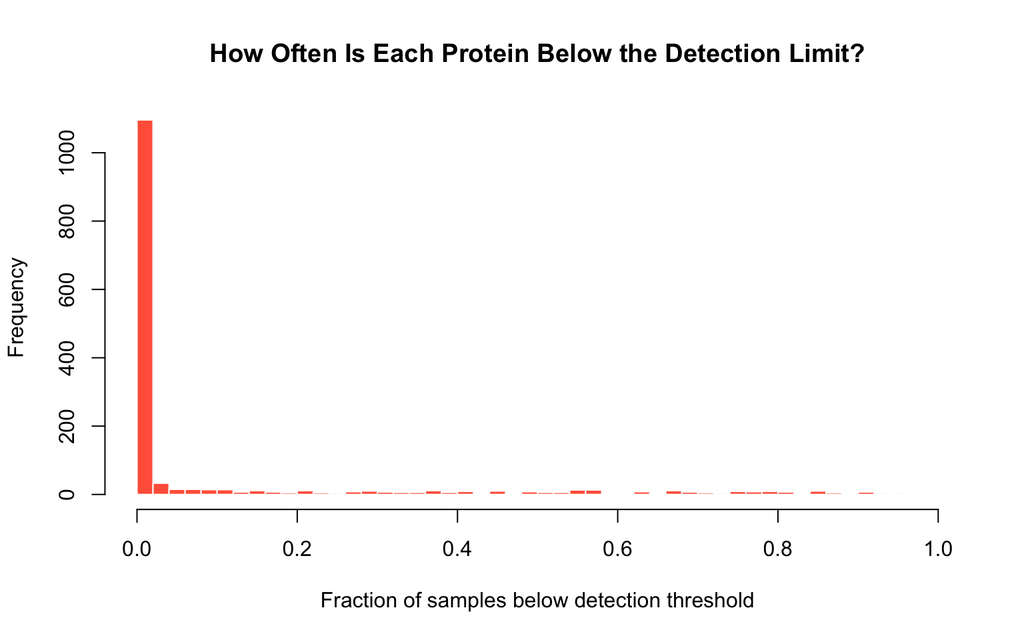

```r
hist(lod_summary$pct_below_lod, breaks = 40,
     main = "How Often Is Each Protein Below the Detection Limit?",
     xlab = "Fraction of samples below detection threshold",
     col  = "tomato", border = "white")
```

```r
cat("\nProteins most often below the detection threshold:\n")
```

```
##
## Proteins most often below the detection threshold:
```

```r
head(lod_summary, 15)
```

```
## # A tibble: 15 × 2
##    olink.assay pct_below_lod
##    <chr>               <dbl>
##  1 FES                 0.994
##  2 MAPT                0.977
##  3 METAP1              0.977
##  4 NGF                 0.964
##  5 IL4                 0.952
##  6 BIRC2               0.949
##  7 XRCC4               0.948
##  8 RAB6B               0.943
##  9 RANGAP1             0.937
## 10 WAS                 0.935
## 11 DGKZ                0.932
## 12 TNNI3               0.922
## 13 FMR1                0.916
## 14 ARNT                0.915
## 15 LTA4H               0.915
```

> Every measuring instrument has a limit of detection (LOD) — a minimum level below which it can’t reliably tell the difference between “a tiny amount” and “none at all.” For 217 proteins in this dataset, more than 30% of samples fell below that threshold.

> This matters because the values reported for those samples aren’t real measurements.
> - We could account for the censoring in the model — tell the model “for these samples, all we know is the protein level was below X” rather than using the number directly.

## 4.5 Is Data Missingness Concentrated in One Group?

```r
plasma_wide %>%
  left_join(
    subject_meta %>% select(sample.sampleKitGuid, subject.ageGroup) %>% distinct(),
    by = "sample.sampleKitGuid"
  ) %>%
  filter(!is.na(subject.ageGroup)) %>%
  group_by(subject.ageGroup) %>%
  summarise(across(where(is.numeric), ~ mean(is.na(.)))) %>%
  pivot_longer(-subject.ageGroup, names_to = "protein", values_to = "pct_missing") %>%
  filter(pct_missing > 0.5) %>%
  count(subject.ageGroup, name = "n_proteins_over_50pct_missing")
```

```
## # A tibble: 2 × 2
##   subject.ageGroup n_proteins_over_50pct_missing
##   <fct>                                    <int>
## 1 Older Adult                                  9
## 2 Young Adult                                  9
```

> Both age groups have exactly 9 proteins missing in more than 50% of their samples. This means protein missingness is not concentrated in one age group over the other. Means the protein most likely doesn’t differently at depending on age group.

## 4.6 How Stable Are Protein Levels Within a Person Over Time?

```r
protein_icc <- plasma |>
  filter(!is.na(olink.NPX_norm)) |>
  group_by(olink.assay) |>
  filter(n() > 10) |>
  ungroup() |>
  group_by(olink.assay, subject.subjectGuid) |>
  mutate(subj_mean = mean(olink.NPX_norm, na.rm = TRUE)) |>
  ungroup() |>
  group_by(olink.assay) |>
  summarise(
    var_between = var(subj_mean, na.rm = TRUE),
    var_within  = mean((olink.NPX_norm - subj_mean)^2, na.rm = TRUE),
    n_subjects  = n_distinct(subject.subjectGuid),
    n_obs       = n(),
    .groups = "drop"
  ) |>
  mutate(
    icc = var_between / (var_between + var_within),
    icc_flag_unreliable = icc < 0.75
  ) |>
  arrange(desc(icc))


cat("Proteins that are highly stable within a person (ICC > 0.7):", sum(protein_icc$icc > 0.7, na.rm = TRUE), "\n")
```

```
## Proteins that are highly stable within a person (ICC > 0.7): 599
```

```r
cat("Proteins that fluctuate a lot within a person (ICC < 0.3):", sum(protein_icc$icc < 0.3, na.rm = TRUE), "\n")
```

```
## Proteins that fluctuate a lot within a person (ICC < 0.3): 155
```

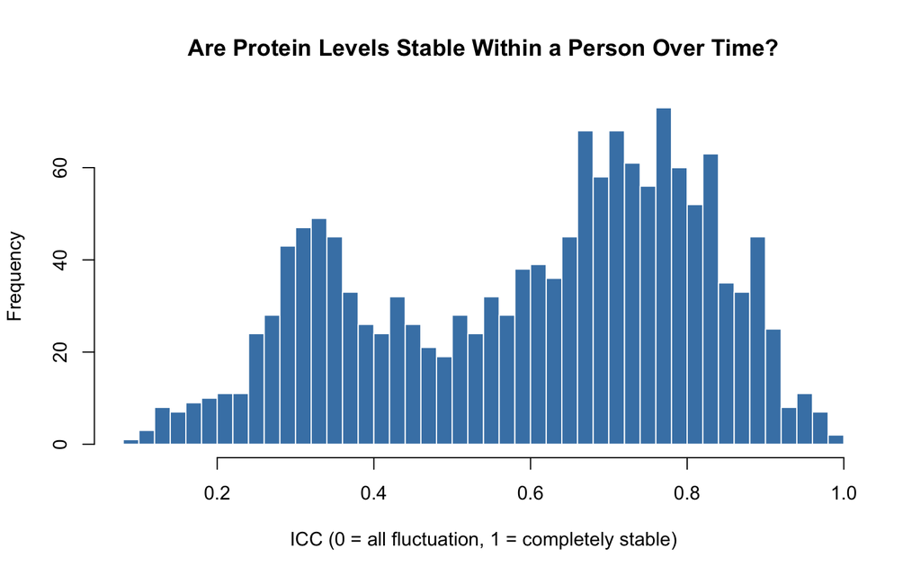

```r
hist(protein_icc$icc, breaks = 40,
     main = "Are Protein Levels Stable Within a Person Over Time?",
     xlab = "ICC (0 = all fluctuation, 1 = completely stable)",
     col  = "steelblue", border = "white")
```

```r
cat("\nTop 10 most stable proteins (each person has a consistent personal level):\n")
```

```
##
## Top 10 most stable proteins (each person has a consistent personal level):
```

```r
head(protein_icc, 10)
```

```
## # A tibble: 10 × 7
##    olink.assay var_between var_within n_subjects n_obs   icc icc_flag_unreliable
##    <chr>             <dbl>      <dbl>      <int> <int> <dbl> <lgl>
##  1 PNLIPRP2         14.0       0.193          96   867 0.986 FALSE
##  2 FOLR3             4.39      0.0688         96   867 0.985 FALSE
##  3 CHIT1             3.32      0.0799         96   867 0.976 FALSE
##  4 CD177             2.10      0.0684         94   788 0.968 FALSE
##  5 TPSAB1            0.461     0.0157         96   867 0.967 FALSE
##  6 LILRB5            0.572     0.0195         96   867 0.967 FALSE
##  7 ACP6              1.24      0.0438         96   867 0.966 FALSE
##  8 KLK1              2.06      0.0785         96   867 0.963 FALSE
##  9 LAIR2             1.38      0.0539         96   867 0.962 FALSE
## 10 PRELP             0.311     0.0144         96   867 0.956 FALSE
```

```r
cat("\nTop 10 most variable proteins (levels shift a lot visit to visit):\n")
```

```
##
## Top 10 most variable proteins (levels shift a lot visit to visit):
```

```r
tail(protein_icc, 10)
```

```
## # A tibble: 10 × 7
##    olink.assay var_between var_within n_subjects n_obs    icc
##    <chr>             <dbl>      <dbl>      <int> <int>  <dbl>
##  1 IL4              0.530       3.37          96   867 0.136
##  2 KRT14            0.0262      0.171         96   867 0.133
##  3 AKT3             0.0558      0.375         96   867 0.129
##  4 MAPT             0.310       2.10          96   867 0.128
##  5 CASP10           0.236       1.62          96   867 0.127
##  6 SERPINB5         0.190       1.32          96   867 0.126
##  7 PTEN             0.123       1.02          96   867 0.108
##  8 IL1B             0.0989      0.822         96   867 0.107
##  9 FMR1             0.368       3.21          96   867 0.103
## 10 CASP1            0.270       2.45          96   867 0.0992
## # ℹ 1 more variable: icc_flag_unreliable <lgl>
```

```r
selected_proteins <- c("IL6", "CXCL8", "IL18", "TNF", "CXCL10", "CCL2",
                       "GZMA", "GZMB", "KLRD1", "CD244", "TNFRSF13B",
                       "CXCL13", "CD163", "CCL7", "VEGFA", "MMP12",
                       "GDF15", "CXCL9")

protein_icc |>
  filter(olink.assay %in% selected_proteins) |>
  arrange(icc) |>
  select(olink.assay, var_between, var_within, icc, icc_flag_unreliable) |>
  print(n = Inf)
```

```
## # A tibble: 18 × 5
##    olink.assay var_between var_within   icc icc_flag_unreliable
##    <chr>             <dbl>      <dbl> <dbl> <lgl>
##  1 TNF              0.115      0.205  0.359 TRUE
##  2 GZMB             0.230      0.342  0.402 TRUE
##  3 CXCL13           0.253      0.229  0.525 TRUE
##  4 CXCL10           0.324      0.255  0.560 TRUE
##  5 CXCL9            0.318      0.228  0.582 TRUE
##  6 GZMA             0.111      0.0759 0.594 TRUE
##  7 IL6              0.610      0.314  0.660 TRUE
##  8 CXCL8            0.201      0.0965 0.675 TRUE
##  9 CD244            0.0691     0.0286 0.707 TRUE
## 10 CCL7             0.398      0.163  0.709 TRUE
## 11 CCL2             0.157      0.0570 0.734 TRUE
## 12 VEGFA            0.149      0.0517 0.742 TRUE
## 13 TNFRSF13B        0.116      0.0312 0.788 FALSE
## 14 CD163            0.168      0.0446 0.790 FALSE
## 15 IL18             0.217      0.0550 0.798 FALSE
## 16 MMP12            0.347      0.0792 0.814 FALSE
## 17 GDF15            0.207      0.0413 0.834 FALSE
## 18 KLRD1            0.273      0.0411 0.869 FALSE
```

```r
cat("\nICC distribution across all proteins:\n")
```

```
##
## ICC distribution across all proteins:
```

```r
summary(protein_icc$icc)
```

```
##    Min. 1st Qu.  Median    Mean 3rd Qu.    Max.
## 0.09919 0.41119 0.65296 0.60148 0.77252 0.98639
```

```r
cat("\nICC < 0.75:", sum(protein_icc$icc < 0.75, na.rm = TRUE), "proteins\n")
```

```
##
## ICC < 0.75: 1027 proteins
```

```r
cat("ICC < 0.50:", sum(protein_icc$icc < 0.50, na.rm = TRUE), "proteins\n")
```

```
## ICC < 0.50: 477 proteins
```

```r
cat("ICC > 0.75:", sum(protein_icc$icc > 0.75, na.rm = TRUE), "proteins\n")
```

```
## ICC > 0.75: 445 proteins
```

> The ICC (Intraclass Correlation Coefficient): Is the variation in this protein mostly about who someone is, or about when the measurement was taken?
> - An ICC close to **1** means a protein is like blood type.
> - An ICC close to **0** means a protein fluctuates a lot from visit to visit within the same person.

> Panel-wide picture:
> - Median ICC of 0.65 across 1,472 proteins
> - 445 of 1,472 proteins (30%) exceed the 0.75 threshold
> - 477 proteins (32%) fall below ICC 0.50

# 5. Bringing the Datasets Together

## 5.1 Final Sample Counts

```r
cat("Total plasma samples:                 ", nrow(plasma_wide), "\n")
```

```
## Total plasma samples:                  867
```

```r
cat("Total RNA-seq samples (unstimulated): ", ncol(whole_nostim), "\n")
```

```
## Total RNA-seq samples (unstimulated):  838
```

```r
cat("Samples with both plasma AND RNA:     ", length(common_plas_nostim), "\n")
```

```
## Samples with both plasma AND RNA:      835
```

```r
cat("Plasma only (no RNA):                 ", nrow(plasma_wide) - length(common_plas_nostim), "\n")
```

```
## Plasma only (no RNA):                  32
```

```r
cat("RNA only (no plasma):                 ", ncol(whole_nostim) - length(common_plas_nostim), "\n")
```

```
## RNA only (no plasma):                  3
```

```r
n_complete_subjects <- subject_meta %>%
  count(subject.subjectGuid) %>%
  filter(n == max(n)) %>%
  nrow()
cat("Subjects with maximum number of visits:", n_complete_subjects, "\n")
```

```
## Subjects with maximum number of visits: 66
```

## 5.2 How Many Study Events Did Each Person Complete?

```r
meta %>%
  filter(include_in_model) %>%
  group_by(subject.subjectGuid) %>%
  summarise(events_present = n_distinct(event), .groups = "drop") %>%
  count(events_present) %>%
  rename(n_subjects = n)
```

```
## # A tibble: 3 × 2
##   events_present n_subjects
##            <int>      <int>
## 1              1          8
## 2              2          7
## 3              3         80
```

> The study had three main event blocks (Flu Year 1, Flu Year 2, Immune Variation). 80 out of 95 subjects have data from all three. Only 15 subjects are missing one or two events.

# 6. Summary:

| What we found | What it means for the model |
| --- | --- |
| 95 out of 96 subjects have 2 or more visits | Each person has enough repeated measurements that the model can learn their individual immune “baseline” and separate it from group-level patterns |
| CMV infection is more common in Older Adults (54% vs 36%) | If we don’t include CMV in the model, apparent age effects may actually be CMV effects in disguise. CMV must be a covariate. |
| CMV-positive young women had more dropout | The people who left the study aren’t a random sample — the model should assume their dropout is related to things we can observe (CMV, sex), not purely accidental |
| Visits are clustered around events, not evenly spaced | Time in the model should be “day within event” (0, 7, or 90) nested inside “which event” — not raw days since enrollment |
| 82 stand-alone samples have no event context | These should be excluded from the model or treated as a separate category |
| 217 proteins are often undetectable | A decision is needed: drop these proteins, or tell the model they’re censored (known to be below a threshold) rather than treating the recorded number as a real measurement |
| 835 of 838 RNA samples have matching protein data | A joint model using both data types is feasible with minimal data loss |
| Protein stability (ICC) varies widely | Stable proteins need a per-person baseline adjustment; fluctuating proteins need time-sensitive modeling |
| Stimulation condition dominates ex vivo gene expression | The stimulated dataset must model stimulation condition as a primary factor before any age or CMV effects can be seen |